# Advanced Static Cartography in R — Exercises with Solutions (Sessions 1–4)

2026-09-27

## Required packages

```r
library(tmap)
library(cols4all)

tmap_mode("plot")   # all maps in this course are static
```

> **Datasets used** — all from the `tmap` package, no downloads needed.

> | Object | Rows | Type | Key variables |
> | --- | --- | --- | --- |
> | `World` | 177 | polygon | `continent`, `economy`, `gdp_cap_est`, `life_exp`, `well_being`, `footprint`, `inequality`, `gender`, `press` |
> | `NLD_prov` | 12 | polygon | `name` |
> | `NLD_muni` | 345 | polygon | `population`, `area`, `dwelling_total`, `dwelling_value`, `dwelling_ownership`, `income_low`, `income_high`, `edu_appl_sci`, `urbanity`, `province` |
> | `NLD_dist` | 3340 | polygon | same variables as `NLD_muni`, district level |

# Exercise 1 — Map type and classification (sessions 1–2)

1. Make a choropleth of the number of dwellings per municipality (`"dwelling_total"`). Why is this map misleading? Make a better map of the same variable.

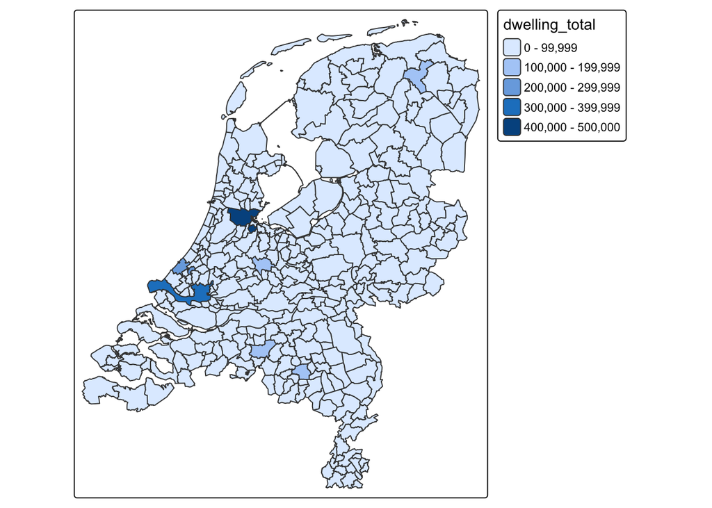

```r
tm_shape(NLD_muni) +
  tm_polygons(fill = "dwelling_total")
```

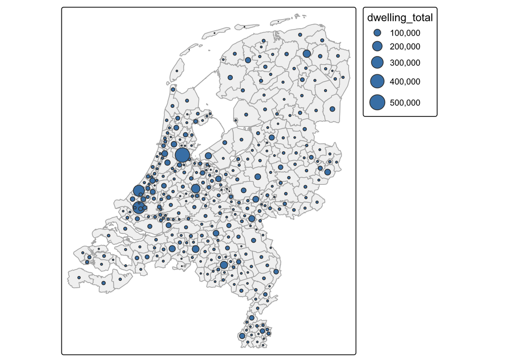

```r
tm_shape(NLD_muni) +
  tm_polygons(fill = "grey95", col = "grey70") +
  tm_bubbles(size = "dwelling_total", fill = "steelblue")
```

> **Answer:** `dwelling_total` is a count: large (rural) municipalities get a lot of visual weight, while the colour is not related to their area. Counts are better shown with proportional symbols.
2. Make a choropleth of the percentage of owner-occupied dwellings (`"dwelling_ownership"`). Show three classification styles side by side in one map: `"pretty"`, `"quantile"` and `"kmeans"`. Tip: repeat the variable name and pass a list of scales. Which map tells which story?

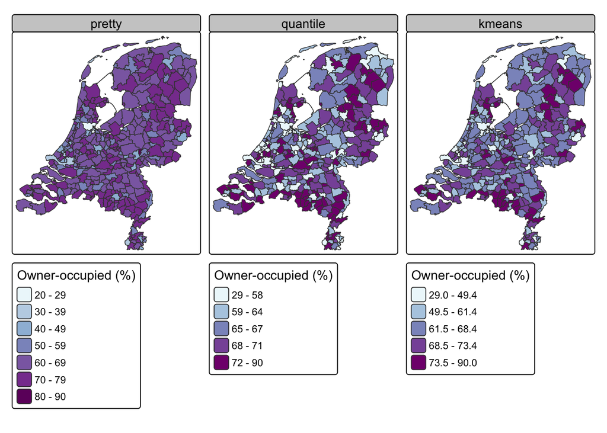

```r
tm_shape(NLD_muni) +
  tm_polygons(
    fill = rep("dwelling_ownership", 3),
    fill.scale = list(
      tm_scale_intervals(style = "pretty", values = "brewer.bu_pu"),
      tm_scale_intervals(style = "quantile", values = "brewer.bu_pu"),
      tm_scale_intervals(style = "kmeans", values = "brewer.bu_pu")),
    fill.legend = tm_legend("Owner-occupied (%)")) +
tm_layout(panel.labels = c("pretty", "quantile", "kmeans"))
```

> **Answer:** `"pretty"` has easy-to-read labels, but most municipalities fall in a few classes. `"quantile"` shows the ranking (every class has the same number of municipalities), which exaggerates small differences in the middle. `"kmeans"` follows the natural groups in the data.
3. Round the `"kmeans"` breaks to numbers that are easy to read and use them as fixed `breaks`. Then try `label.style = "continuous"` in `tm_scale_intervals()`. Which legend do you prefer?

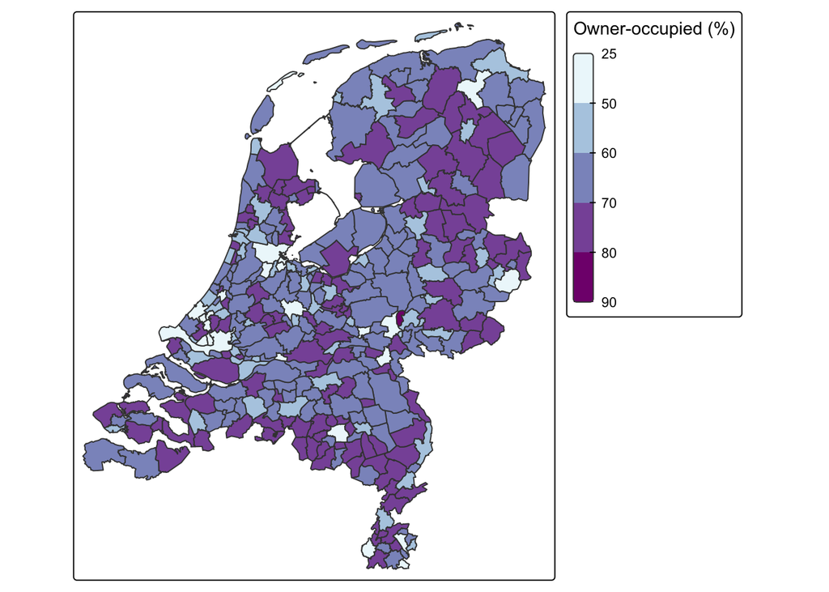

```r
tm_shape(NLD_muni) +
  tm_polygons(
    fill = "dwelling_ownership",
    fill.scale = tm_scale_intervals(
      breaks = c(25, 50, 60, 70, 80, 90),
      values = "brewer.bu_pu",
      label.style = "continuous"),
    fill.legend = tm_legend("Owner-occupied (%)"))
```

4. Combine both variables in one map: symbol size for `"dwelling_total"` and symbol fill color for `"dwelling_ownership"`. Format the size legend labels in thousands (`tm_label_format(big.num.abbr = ...)`).

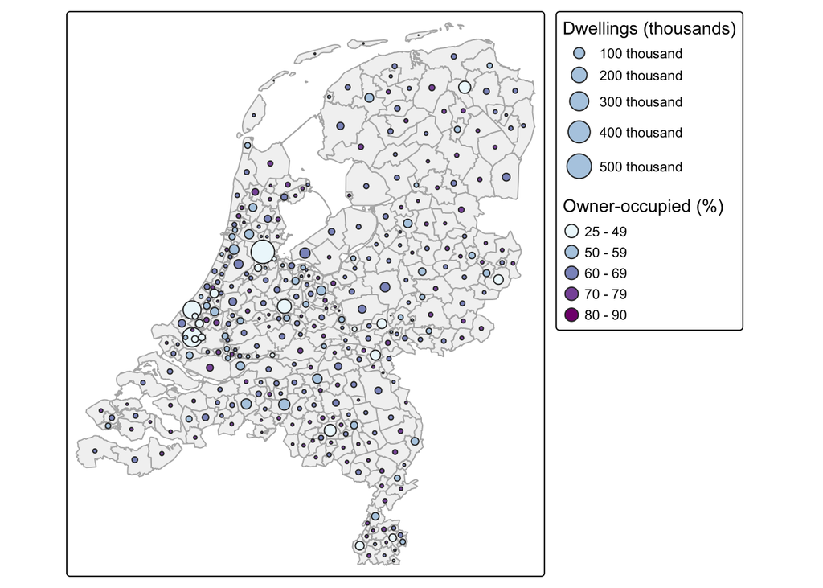

```r
tm_shape(NLD_muni) +
  tm_polygons(fill = "grey95", col = "grey70") +
  tm_bubbles(
    size = "dwelling_total",
    fill = "dwelling_ownership",
    col = "grey20",
    size.scale = tm_scale_continuous(
      label.format = tm_label_format(big.num.abbr = c(thousand = 3))),
    size.legend = tm_legend("Dwellings (thousands)"),
    fill.scale = tm_scale_intervals(
      breaks = c(25, 50, 60, 70, 80, 90),
      values = "brewer.bu_pu"),
    fill.legend = tm_legend("Owner-occupied (%)"))
```

# Exercise 2 — Visual hierarchy and layout (session 2)

1. Make a choropleth of the percentage of people with a low income (`"income_low"`) at district level (`NLD_dist`). Remove the district borders and add municipality borders (thin) and province borders (thick).

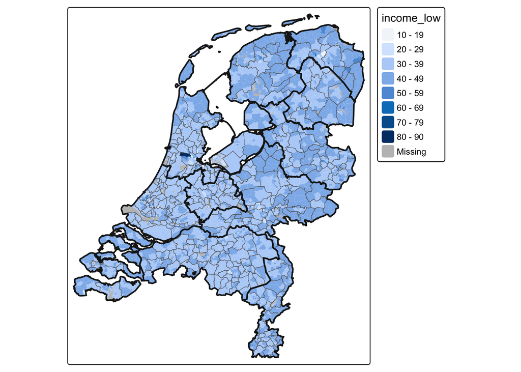

```r
tm_shape(NLD_dist) +
  tm_polygons(fill = "income_low", col = NULL) +
tm_shape(NLD_muni) +
  tm_borders(lwd = 0.5, col = "grey40") +
tm_shape(NLD_prov) +
  tm_borders(lwd = 2, col = "grey10")
```

2. Finish the map: a title that states the message, a legend title with units, a scale bar and credits (`"Data: Statistics Netherlands (2022)"`). Place the title above the map, and group the scale bar and credits in the empty space. Use `tmap_design_mode()` if components do not end up where you expect them.

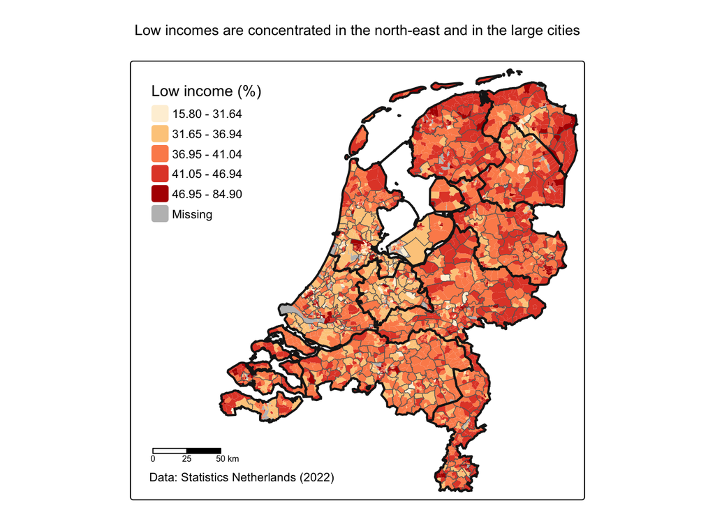

```r
tm_low = tm_shape(NLD_dist) +
  tm_polygons(
    fill = "income_low",
    fill.scale = tm_scale_intervals(style = "kmeans", values = "brewer.or_rd"),
    fill.legend = tm_legend("Low income (%)", group_id = "top"),
    col = NULL) +
tm_shape(NLD_muni) +
  tm_borders(lwd = 0.5, col = "grey40") +
tm_shape(NLD_prov) +
  tm_borders(lwd = 2, col = "grey10") +
tm_title("Low incomes are concentrated in the north-east and in the large cities",
  position = tm_pos_out("center", "top", pos.h = "left")) +
tm_scalebar(breaks = c(0, 25, 50), group_id = "bottom") +
tm_credits("Data: Statistics Netherlands (2022)", group_id = "bottom") +
tm_components("top", position = tm_pos_in("left", "top"), frame = FALSE) +
tm_components("bottom", position = tm_pos_in("left", "bottom")) +
tm_layout(inner.margins = c(0.02, 0.25, 0.02, 0.02))
tm_low
```

3. Export the map to a png file of 7 × 8 inches with 300 dpi. Open the file: does it look the same as in the plot pane? Adjust `scale` if necessary.

```r
tmap_save(tm_low, "income_low.png", width = 7, height = 8, dpi = 300)
tmap_save(tm_low, "income_low.png", width = 7, height = 8, dpi = 300, scale = 0.8)
```

# Exercise 3 — Color palettes (session 3)

1. Open the cols4all dashboard (`c4a_gui()`). Which palette type (categorical, sequential, diverging) fits the variables `"economy"`, `"footprint"` and `"press"` of `World`? Select a color-blind friendly palette for each.

```r
c4a_gui()
```

> **Answer:** `"economy"` is categorical (7 categories), `"footprint"` sequential (low → high), `"press"` diverging when a meaningful midpoint is used (e.g. 50), otherwise sequential.
2. Make the three maps with your palettes (use `tm_crs("auto")`). For `"press"`, set a `midpoint`.

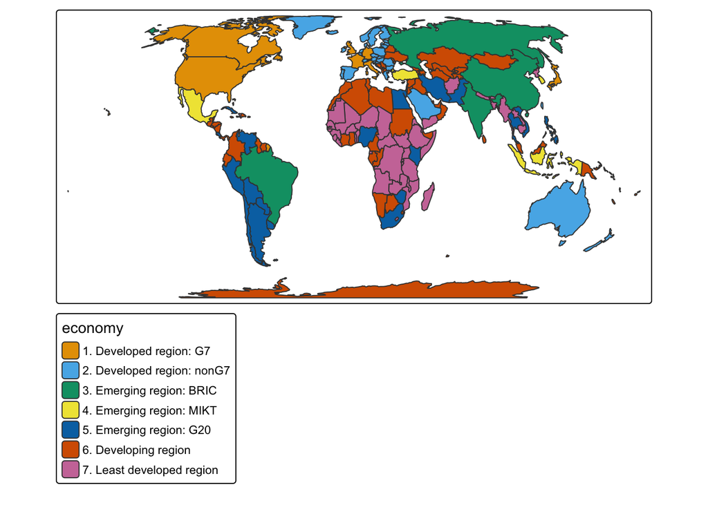

```r
tm_shape(World) +
  tm_polygons(fill = "economy",
    fill.scale = tm_scale_categorical(values = "misc.okabe")) +
tm_crs("auto")
```

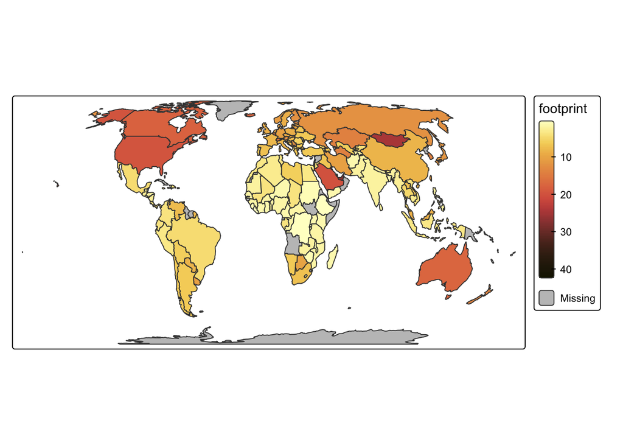

```r
tm_shape(World) +
  tm_polygons(fill = "footprint",
    fill.scale = tm_scale_continuous(values = "-scico.lajolla")) +
tm_crs("auto")
```

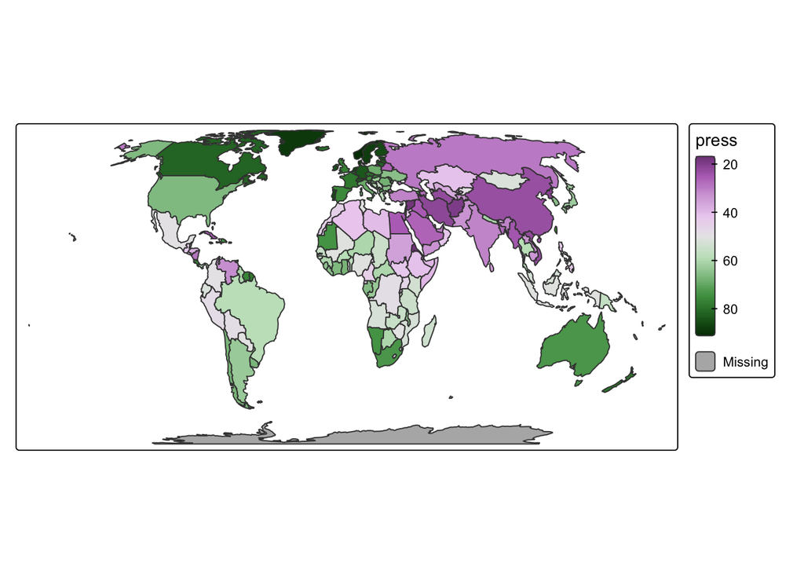

```r
tm_shape(World) +
  tm_polygons(fill = "press",
    fill.scale = tm_scale_continuous(values = "pu_gn_div", midpoint = 50)) +
tm_crs("auto")
```

# Exercise 4 — Bivariate choropleth (session 4)

1. Is there a relationship between the percentage of people with a high income (`"income_high"`) and the percentage with a university degree (`"edu_appl_sci"`)? Make two facets of `NLD_muni` first.

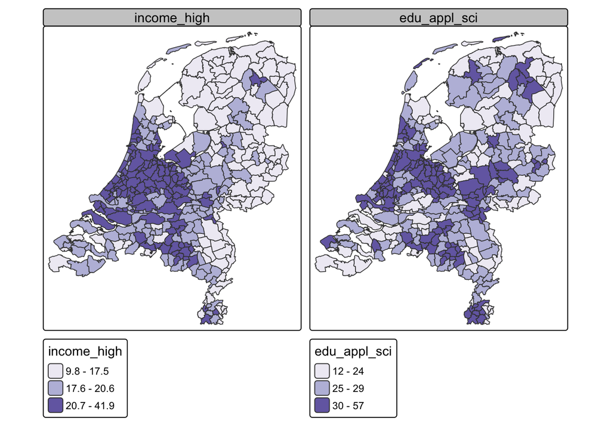

```r
tm_shape(NLD_muni) +
  tm_polygons(fill = c("income_high", "edu_appl_sci"),
    fill.scale = tm_scale_intervals(style = "quantile", n = 3, values = "brewer.purples"))
```

2. Now make a bivariate choropleth of the same two variables, with 3 × 3 quantile classes and labels `"L"`, `"M"`, `"H"`.

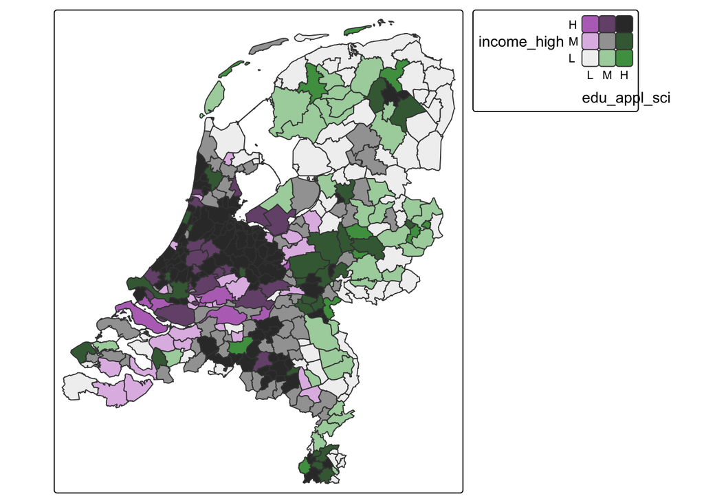

```r
tm_shape(NLD_muni) +
  tm_polygons(
    fill = tm_vars(c("income_high", "edu_appl_sci"), multivariate = TRUE),
    fill.scale = tm_scale_bivariate(
      scale1 = tm_scale_intervals(style = "quantile", n = 3, labels = c("L", "M", "H")),
      scale2 = tm_scale_intervals(style = "quantile", n = 3, labels = c("L", "M", "H"))))
```

3. Try a few bivariate palettes (`c4a_palettes(type = "bivs")`) and improve the legend with `tm_legend_bivariate()`: axis labels, square items, placed inside the map frame. Add province borders.

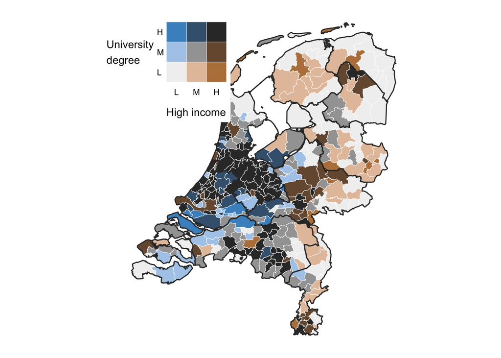

```r
tm_shape(NLD_muni) +
  tm_polygons(
    fill = tm_vars(c("income_high", "edu_appl_sci"), multivariate = TRUE),
    fill.scale = tm_scale_bivariate(
      scale1 = tm_scale_intervals(style = "quantile", n = 3, labels = c("L", "M", "H")),
      scale2 = tm_scale_intervals(style = "quantile", n = 3, labels = c("L", "M", "H")),
      values = "bu_br_bivs"),
    fill.legend = tm_legend_bivariate(
      xlab = "High income", ylab = "University\ndegree",
      item.r = 0, item.width = 2, item.height = 2, frame = FALSE,
      position = tm_pos_in("left", "top")),
    col = "white", lwd = 0.5) +
tm_shape(NLD_prov) +
  tm_borders(col = "grey20", lwd = 1.5) +
tm_layout(frame = FALSE, inner.margins = c(0.05, 0.15, 0.05, 0.05))
```

4. Which map answers the question in (a) best: the facets or the bivariate choropleth? Where does the relationship break down?

> **Answer:** The bivariate map shows the relationship directly: most municipalities are on the diagonal (both low or both high). Off-diagonal colors show the exceptions, e.g. university towns with many graduates but relatively few high incomes (student populations).